# 4. Phylogenetic trees - solutions

Author

EPFL - SV - BIO-463

Published

March 12, 2024

## Exercise 2: Plot and analyze the gene tree

Use the R packages *ape* to plot and annotate your tree.

1. Load the file *RAxML_bipartitions.Homologs* using *read.tree*
2. Plot the tree using *plot.phylo*
3. Re-root the tree at the base of all bird genes (find all tree tips corresponding to *penguin* using *grep*, then *[getMRCA](https://www.rdocumentation.org/packages/ape/versions/5.6-2/topics/mrca)* and *root*
4. Display the bootstrap values > 80 with *nodelabels*
5. Annotate the tree by displaying the *Barn_owl*, *human* and *Atlantic_salmon* genes in 3 different colors

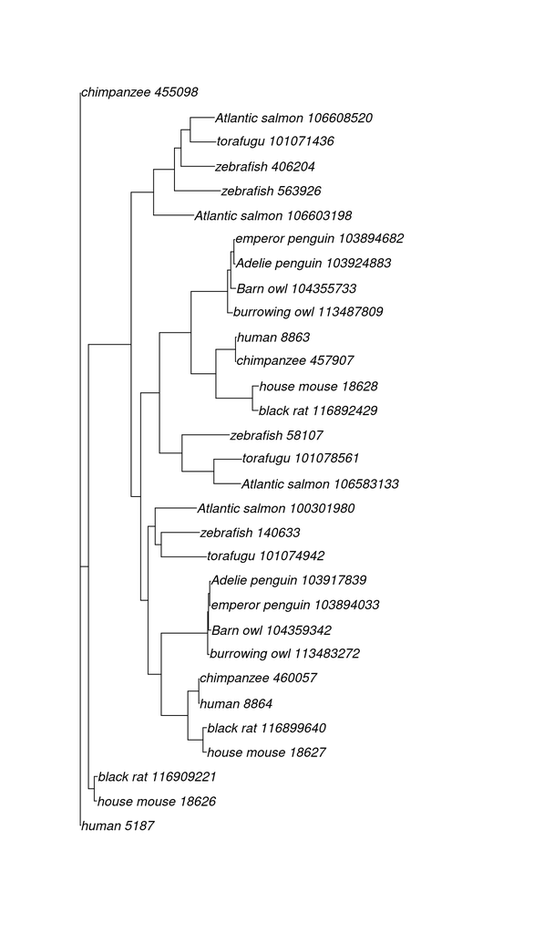

```r
library(ape)

# read the output of RAxML - the reconstructed phylogeny with bootstrap values, and plot it
tree = read.tree("RAxML_bipartitions.Homologs")
plot.phylo(tree)
```

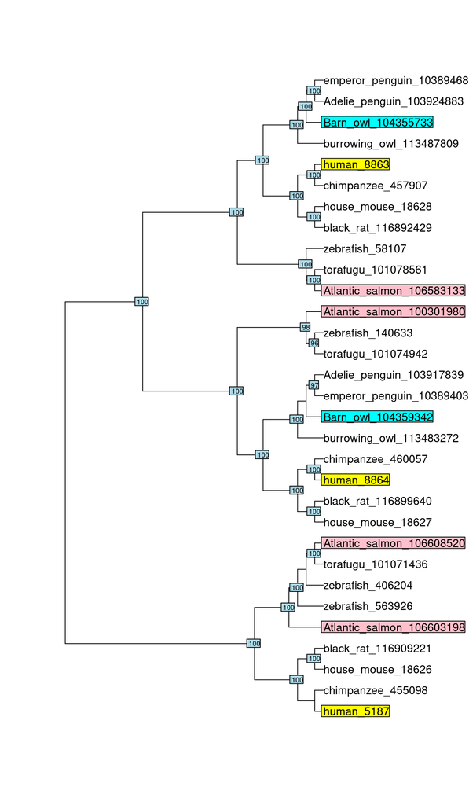

```r
# the tree is "unrooted", we force the root at the base of all birds:
# select all tips with the name "penguin" (grep), then find their ancestor (getMRCA) and define it as the tree root (root(...))
root = getMRCA(tree, grep("penguin", tree$tip.label))
tree = root(tree, node=root, resolve.root=T)

# select bootstrap values > 80 (the node label is the bootstrap values in text, need to convert to number first)
ns = which(as.numeric(tree$node.label) > 80)
nb.tip = length(tree$tip.label)

# select: 1. "human" genes, 2. "salmon" genes, 3. "owl" genes, 4. all the rest
# using grep to identify labels containing a given substring
# "all the rest" is 1,...,N from which we remove the numbers already selected
ihs = grep("human", tree$tip.label)
ipt = grep("salmo", tree$tip.label)
icn = grep("Barn_owl", tree$tip.label)
irest = (1:length(tree$tip.label))[-c(ihs,ipt,icn)]

# re-plot the tree with only bootstrap values>80, and selected genes in color ('bg'=background color of the label)
par(oma=c(0,0,0,8), xpd=NA)
plot.phylo(tree, show.tip.label=F, use.edge.length=F)
nodelabels(tree$node.label[ns], node=ns+nb.tip, cex=0.6)
tiplabels(tree$tip.label[ihs], ihs, adj=c(0,.5))
tiplabels(tree$tip.label[ipt], ipt, bg='pink', adj=c(0,.5))
tiplabels(tree$tip.label[icn], icn, bg='cyan', adj=c(0,.5))
tiplabels(tree$tip.label[irest], irest, bg=0, frame='none', adj=c(0,.5))
```

6. Based on this tree, how many paralogs of this gene exist in mammals, in birds and in fishes?
- There are 3 paralogs of this gene in mammals, 2 in birds and 4 in fishes.
7. Which *rat* gene is the ortholog of *human_5187*?
- *black_rat_116909221* is the ortholog of *human_5187*.

## Exercise 3: Manipulate the gene tree

Use the methods *[drop.tip, keep.tip and extract.clade](https://www.rdocumentation.org/packages/ape/versions/5.6-2/topics/drop.tip)* to plot the following subtrees:

1. All non-fish species (remove all *salmon*, *zebrafish* and *torafugu*)
2. The clade containing *human_8863* and *house_mouse_18628* (a clade contains all descendents of the last common ancestor of these 2 leaves)
3. Only the birds (*penguins* and *owls*)

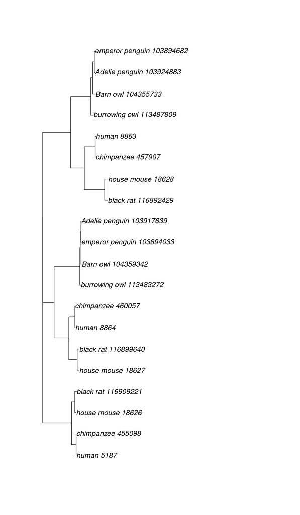

```r
par(oma=c(0,0,0,5), xpd=NA)
subtree.1 = drop.tip(tree, grep("fugu|salmo|zebra", tree$tip.label))
plot.phylo(subtree.1)
```

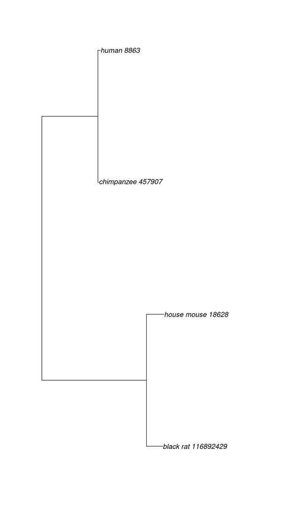

```r
subtree.2 = extract.clade(tree, node=getMRCA(tree, grep("_8863|_18628", tree$tip.label)))
plot.phylo(subtree.2)
```

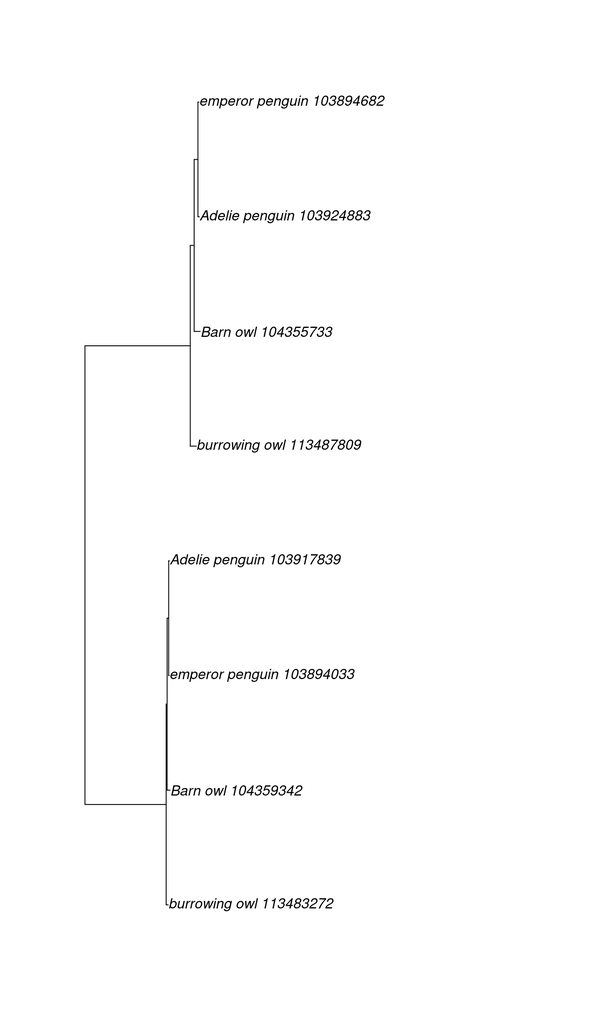

```r
subtree.3 = keep.tip(tree, grep("penguin|owl", tree$tip.label))
plot.phylo(subtree.3 )
```